# First Data Set

# Which type of emission has emitted the most pollutant in years 2002?

### Year 2002

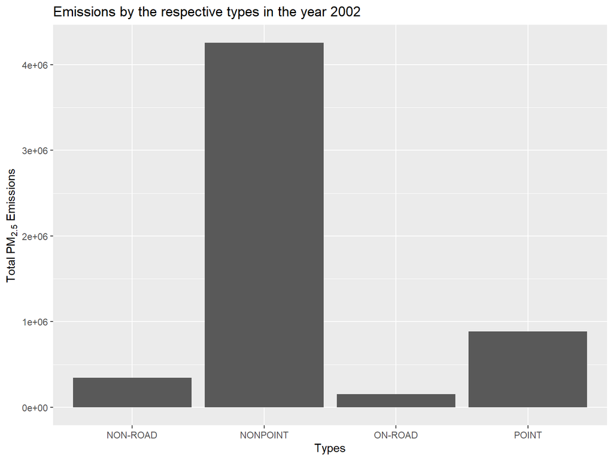

```r
if(!exists("NEI")){
    NEI <- readRDS("./R_course/summarySCC_PM25.rds")
}
if(!exists("SCC")){
    SCC <- readRDS("./R_course/Source_Classification_Code.rds")
}
# merge the two data sets
if(!exists("NEISCC")){
    NEISCC <- merge(NEI, SCC, by="SCC")
}

library(ggplot2)
#Subsetting only the data of year 2002
subsetNEI <- NEI[NEI$year==2002, ]
aggregatedTotalByYear <- aggregate(Emissions ~ type+fips, subsetNEI, sum)
g <- ggplot(aggregatedTotalByYear, aes(factor(type), Emissions))
g <- g + geom_bar(stat="identity") +
    xlab("Types") +
    ylab(expression('Total PM'[2.5]*" Emissions")) +
    ggtitle('Emissions by the respective types in the year 2002')
print(g)
```

# Which type of emission has emitted the most pollutant in years 2005?

### Year 2005

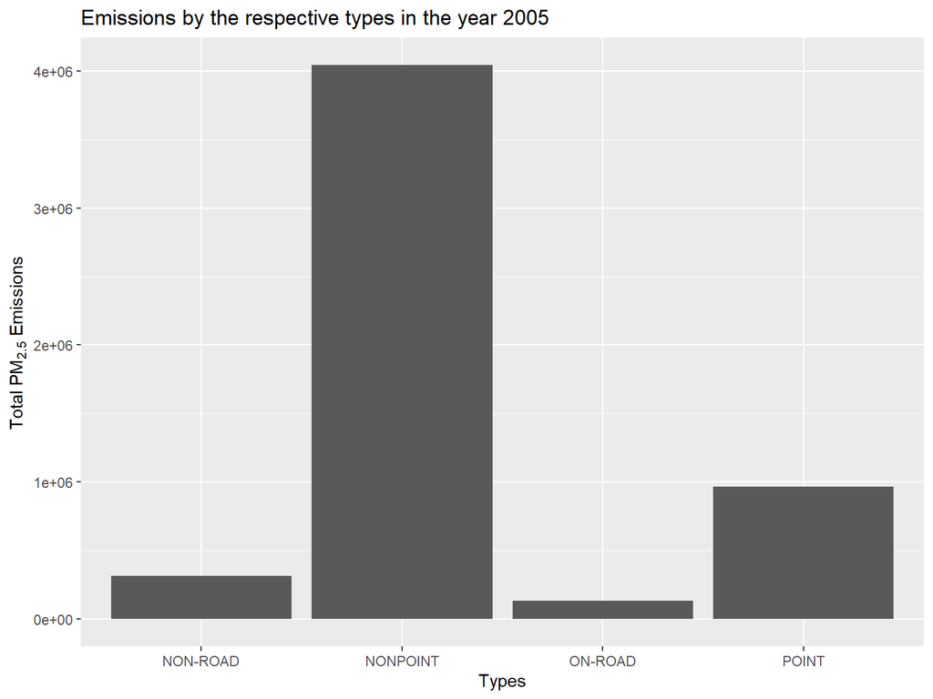

```r
if(!exists("NEI")){
    NEI <- readRDS("./R_course/summarySCC_PM25.rds")
}
if(!exists("SCC")){
    SCC <- readRDS("./R_course/Source_Classification_Code.rds")
}
# merge the two data sets
if(!exists("NEISCC")){
    NEISCC <- merge(NEI, SCC, by="SCC")
}

library(ggplot2)
#Subsetting only the data of year 2005
subsetNEI <- NEI[NEI$year==2005, ]
aggregatedTotalByYear <- aggregate(Emissions ~ type+fips, subsetNEI, sum)
g <- ggplot(aggregatedTotalByYear, aes(factor(type), Emissions))
g <- g + geom_bar(stat="identity") +
    xlab("Types") +
    ylab(expression('Total PM'[2.5]*" Emissions")) +
    ggtitle('Emissions by the respective types in the year 2005')
print(g)
```

# Which type of emission has emitted the most pollutant in years 2008?

### Year 2008

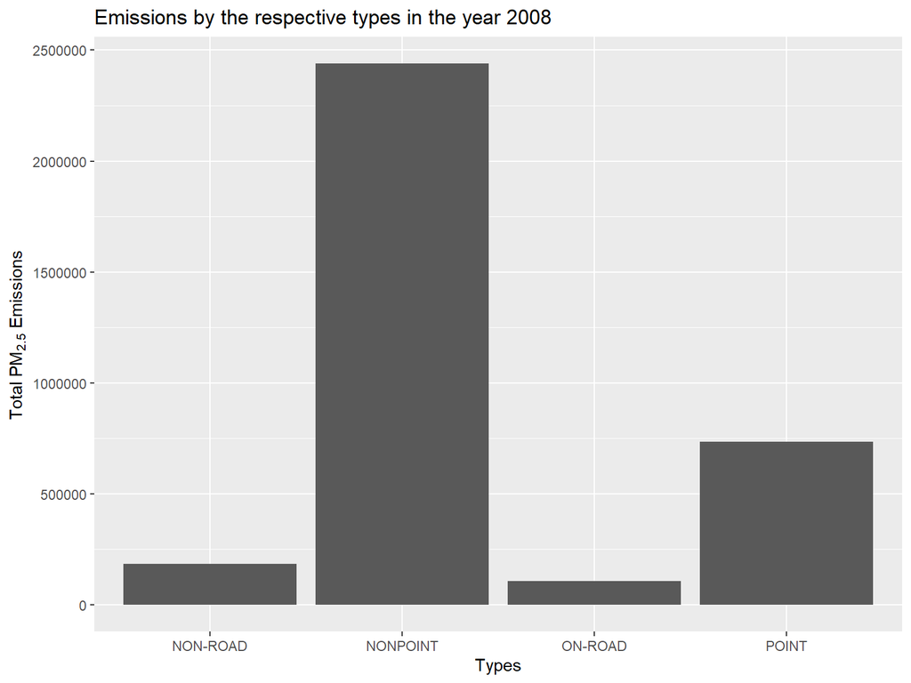

```r
if(!exists("NEI")){
    NEI <- readRDS("./R_course/summarySCC_PM25.rds")
}
if(!exists("SCC")){
    SCC <- readRDS("./R_course/Source_Classification_Code.rds")
}

library(ggplot2)
#Subsetting only the data of year 2008
subsetNEI <- NEI[NEI$year==2008, ]
aggregatedTotalByYear <- aggregate(Emissions ~ type+fips, subsetNEI, sum)
g <- ggplot(aggregatedTotalByYear, aes(factor(type), Emissions))
g <- g + geom_bar(stat="identity") +
    xlab("Types") +
    ylab(expression('Total PM'[2.5]*" Emissions")) +
    ggtitle('Emissions by the respective types in the year 2008')
print(g)
```

# Among Industrial Processes and Waste Disposal sources which source has emitted the most pollution?

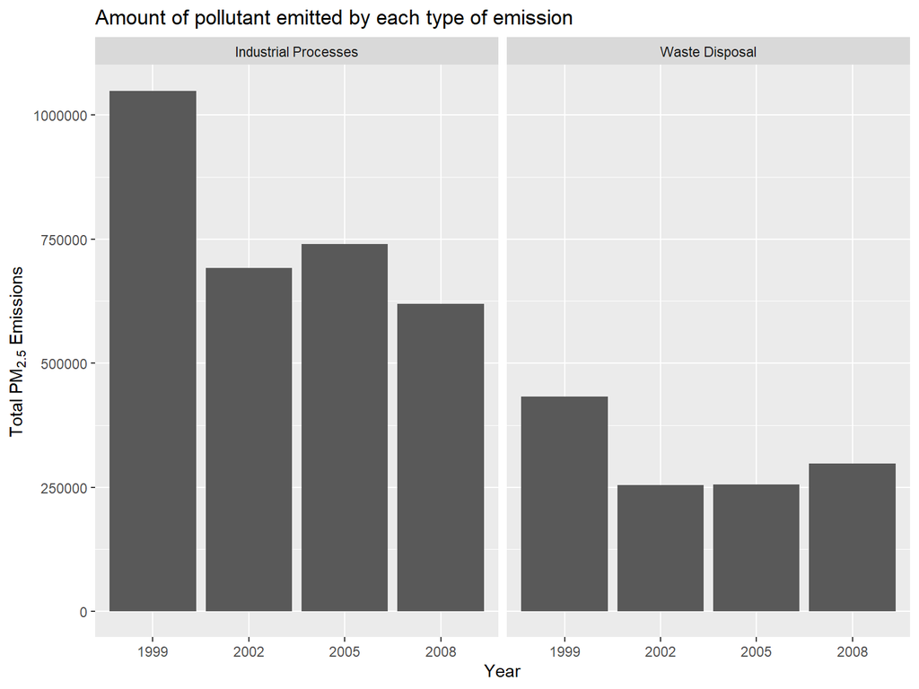

```r
if(!exists("NEI")){
    NEI <- readRDS("./R_Course/summarySCC_PM25.rds")
}
if(!exists("SCC")){
    SCC <- readRDS("./R_course/Source_Classification_Code.rds")
}
# merge the two data sets
if(!exists("NEISCC")){
    NEISCC <- merge(NEI, SCC, by="SCC")
}

library(ggplot2)
library(ggplot2)

# 24510 is Baltimore, see plot2.R, 06037 is LA CA
# Searching for ON-ROAD type in NEI
# Don't actually know it this is the intention, but searching for 'motor' in SCC only gave a subset (non-cars)
sub <- NEISCC[(NEISCC$SCC.Level.One=="Industrial Processes"|NEISCC$SCC.Level.One=="Waste Disposal, Treatment, and Recovery"),]
aggregatedTotalByYearAndType <- aggregate(Emissions ~ year + SCC.Level.One, sub, sum)
aggregatedTotalByYearAndType$SCC.Level.One[aggregatedTotalByYearAndType$SCC.Level.One=="Waste Disposal, Treatment, and Recovery"] <- "Waste Disposal"

g <- ggplot(aggregatedTotalByYearAndType, aes(factor(year), Emissions))
 g <- g + facet_grid(. ~ SCC.Level.One)
g <- g + geom_bar(stat="identity") +
    xlab("Year") +
    ylab(expression('Total PM'[2.5]*" Emissions")) +
    ggtitle('Amount of pollutant emitted by each type of emission')
plot(g)
```

# Across the United States, how have emissions from coal combustion-related sources changed from 1999–2008?

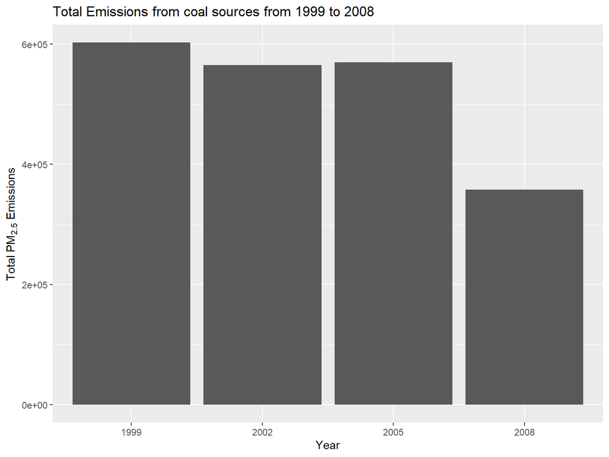

```r
NEI <- readRDS("./R_course/summarySCC_PM25.rds")
SCC <- readRDS("./R_course/Source_Classification_Code.rds")

# merge the two data sets
 NEISCC <- merge(NEI, SCC, by="SCC")


library(ggplot2)
library(ggplot2)

# fetch all NEIxSCC records with Short.Name (SCC) Coal
coalMatches <- grepl("coal", NEISCC$Short.Name, ignore.case=TRUE)
subsetNEISCC <- NEISCC[coalMatches, ]

aggregatedTotalByYear <- aggregate(Emissions ~ year, subsetNEISCC, sum)
g <- ggplot(aggregatedTotalByYear, aes(factor(year), Emissions))
g <- g + geom_bar(stat="identity") +
  xlab("Year") +
  ylab(expression('Total PM'[2.5]*" Emissions")) +
  ggtitle('Total Emissions from coal sources from 1999 to 2008')
print(g)
```

# Across the United States, how have emissions from Spreader Stoker-related sources changed from 1999–2008?

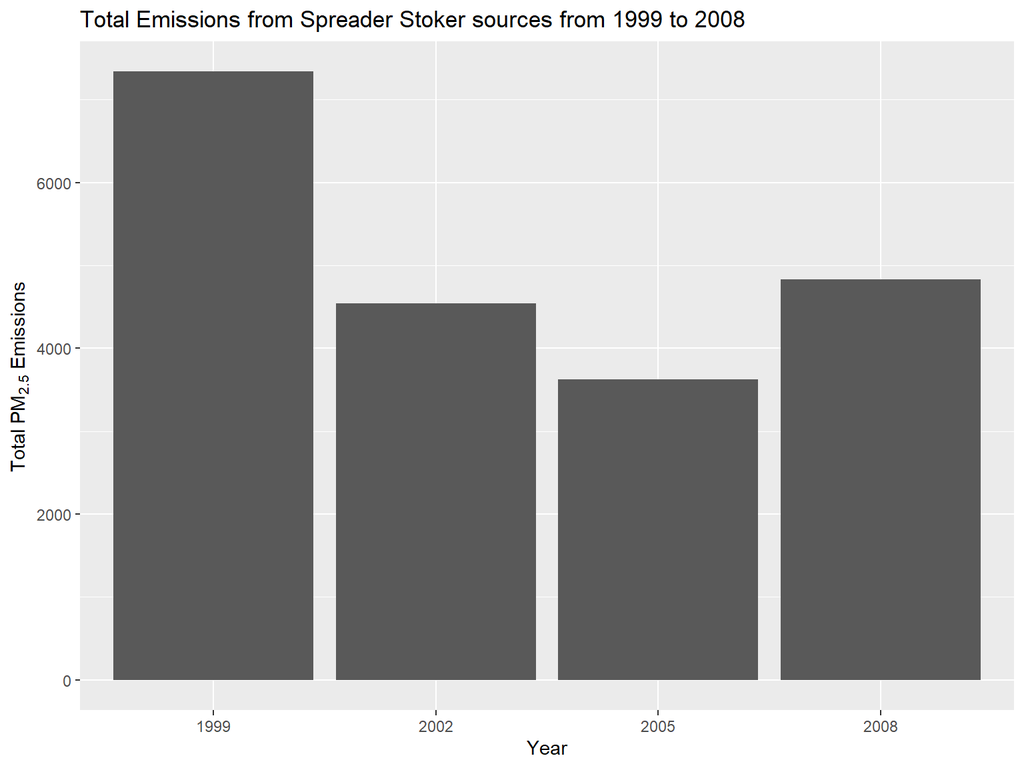

```r
NEI <- readRDS("./R_course/summarySCC_PM25.rds")
SCC <- readRDS("./R_course/Source_Classification_Code.rds")

# merge the two data sets
 NEISCC <- merge(NEI, SCC, by="SCC")


library(ggplot2)
library(ggplot2)

# fetch all NEIxSCC records with Short.Name (SCC) Spreader Stoker
ElectricgenMatches <- grepl("Spreader Stoker", NEISCC$Short.Name, ignore.case=TRUE)
subsetNEISCC <- NEISCC[ElectricgenMatches, ]

aggregatedTotalByYear <- aggregate(Emissions ~ year, subsetNEISCC, sum)
g <- ggplot(aggregatedTotalByYear, aes(factor(year), Emissions))
g <- g + geom_bar(stat="identity") +
  xlab("Year") +
  ylab(expression('Total PM'[2.5]*" Emissions")) +
  ggtitle('Total Emissions from Spreader Stoker sources from 1999 to 2008')
print(g)
```

# Showing the cities to be analyzed on the world map

```r
#Using packages to show the cities to be analysied
library(leaflet)
library(dplyr)
df <- data.frame(lat=c(39.2904,34.0522),lng=c(-76.6122,-118.2437),pop=c(619493,10000000))
df %>%
    leaflet() %>%
     addTiles() %>%
     addCircles(weight =1 ,radius =sqrt(df$pop) * 80)
```

[interactive chart not shown]

# Of the four types of sources indicated by the type (point, nonpoint, onroad, nonroad) variable, which of these four sources have seen decreases in emissions from 1999–2008 for Baltimore City? Which have seen increases in emissions from 1999–2008?

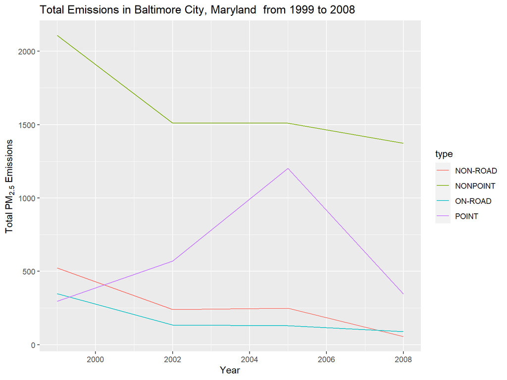

```r
NEI <- readRDS("./R_course/summarySCC_PM25.rds")
SCC <- readRDS("./R_course/Source_Classification_Code.rds")
library(ggplot2)
library(ggplot2)
# 24510 is Baltimore.
#Combing three columns now (Emission,Year and type)
subsetNEI <- NEI[NEI$fips=="24510", ]
aggregatedTotalByYearAndType <- aggregate(Emissions ~ year + type, subsetNEI, sum)
# Use the ggplot2 plotting system to make a plot.
g <- ggplot(aggregatedTotalByYearAndType, aes(year, Emissions, color = type))
g <- g + geom_line() +
  xlab("Year") +
  ylab(expression('Total PM'[2.5]*" Emissions")) +
  ggtitle('Total Emissions in Baltimore City, Maryland  from 1999 to 2008')
print(g)
```

# Compare the emissions of four type of source between Baltimore City and Los Angeles county.Which type has made a greater impact on them?

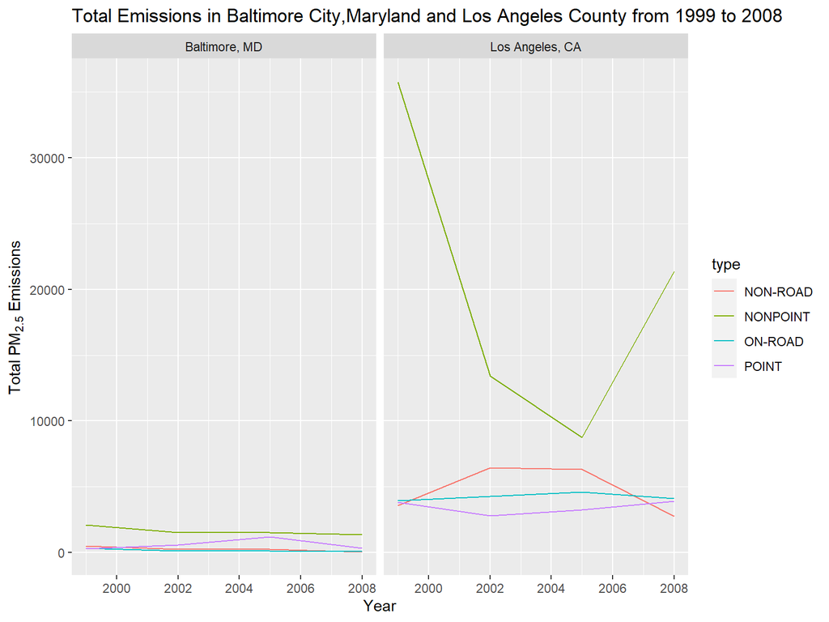

```r
NEI <- readRDS("./R_course/summarySCC_PM25.rds")
SCC <- readRDS("./R_course/Source_Classification_Code.rds")
library(ggplot2)
library(ggplot2)
# 24510 is Baltimore.
#Combing three columns now (Emission,Year and type)
subsetNEI <- NEI[(NEI$fips=="24510"|NEI$fips=="06037"), ]
aggregatedTotalByYearAndType <- aggregate(Emissions ~ year + type+fips, subsetNEI, sum)
aggregatedTotalByYearAndType$fips[aggregatedTotalByYearAndType$fips=="24510"] <- "Baltimore, MD"
aggregatedTotalByYearAndType$fips[aggregatedTotalByYearAndType$fips=="06037"] <- "Los Angeles, CA"
# Use the ggplot2 plotting system to make a plot.
g <- ggplot(aggregatedTotalByYearAndType, aes(year, Emissions, color = type))
g <- g + geom_line() +facet_grid(.~fips)+
    xlab("Year") +
    ylab(expression('Total PM'[2.5]*" Emissions")) +
    ggtitle('Total Emissions in Baltimore City,Maryland and Los Angeles County from 1999 to 2008')
print(g)
```

# How have emissions from Heavy Duty vehicle sources changed from 1999–2008 in Baltimore city?

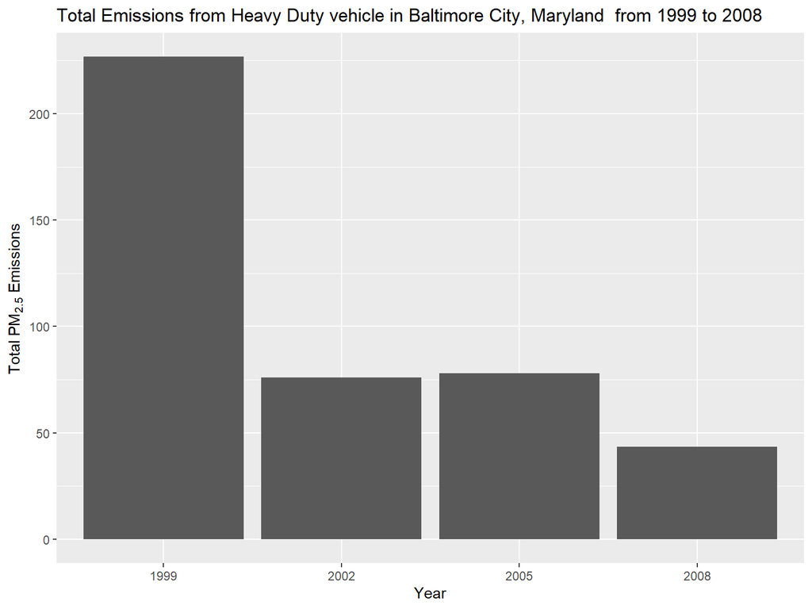

```r
NEI <- readRDS("./R_course/summarySCC_PM25.rds")
SCC <- readRDS("./R_course/Source_Classification_Code.rds")

# merge the two data sets
NEISCC <- merge(NEI, SCC, by="SCC")


library(ggplot2)
library(ggplot2)

# fetch all NEIxSCC records with Short.Name (SCC) Coal
HeavyDuty <- grepl("Heavy Duty", NEISCC$Short.Name, ignore.case=TRUE)
subsetNEISCC <- NEISCC[HeavyDuty & NEISCC$fips=="24510", ]

aggregatedTotalByYear <- aggregate(Emissions ~ year, subsetNEISCC, sum)
g <- ggplot(aggregatedTotalByYear, aes(factor(year), Emissions))
g <- g + geom_bar(stat="identity") +
    xlab("Year") +
    ylab(expression('Total PM'[2.5]*" Emissions")) +
    ggtitle('Total Emissions from Heavy Duty vehicle in Baltimore City, Maryland  from 1999 to 2008')
print(g)
```

# How have emissions from motor vehicle sources changed from 1999–2008 in Baltimore City?

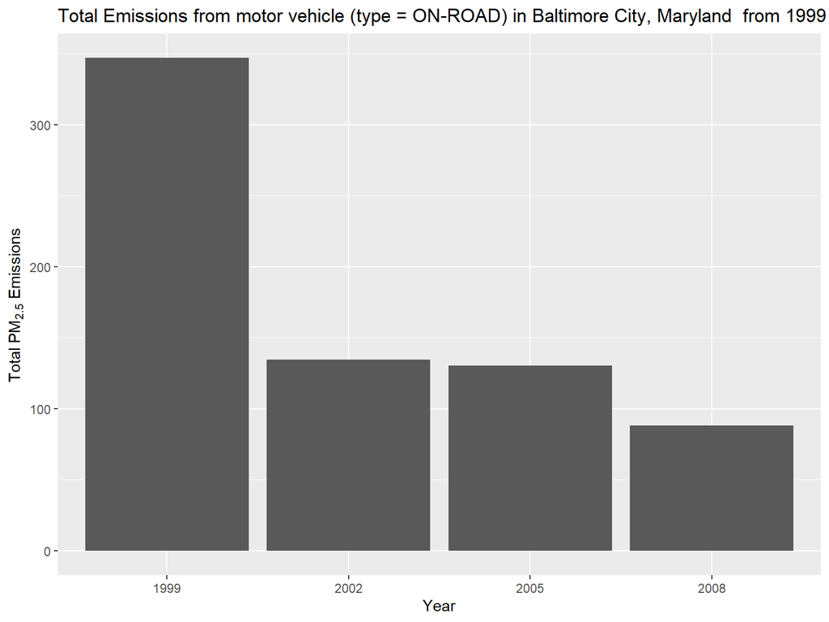

```r
## This first line will likely take a few seconds. Be patient!
if(!exists("NEI")){
  NEI <- readRDS("./R_course/summarySCC_PM25.rds")
}
if(!exists("SCC")){
  SCC <- readRDS("./R_course/Source_Classification_Code.rds")
}
# merge the two data sets
if(!exists("NEISCC")){
  NEISCC <- merge(NEI, SCC, by="SCC")
}

library(ggplot2)
# 24510 is Baltimore
# Searching for ON-ROAD type in NEI
# Don't actually know it this is the intention, but searching for 'motor' in SCC only gave a subset (non-cars)
subsetNEI <- NEI[NEI$fips=="24510" & NEI$type=="ON-ROAD", ]
aggregatedTotalByYear <- aggregate(Emissions ~ year, subsetNEI, sum)
g <- ggplot(aggregatedTotalByYear, aes(factor(year), Emissions))
g <- g + geom_bar(stat="identity") +
  xlab("Year") +
  ylab(expression('Total PM'[2.5]*" Emissions")) +
  ggtitle('Total Emissions from motor vehicle (type = ON-ROAD) in Baltimore City, Maryland  from 1999 to 2008')
print(g)
```

# Compare emissions from motor vehicle sources in Baltimore City with emissions from motor vehicle sources in Los Angeles County, California. Which city has seen greater changes over time in motor vehicle emissions?

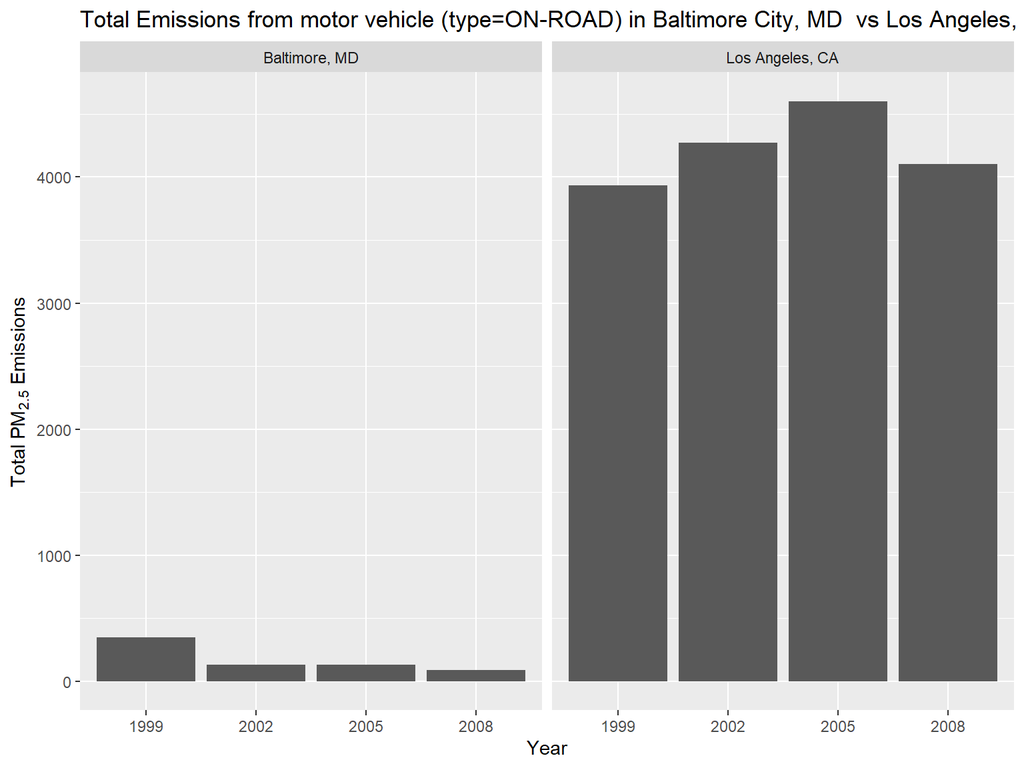

```r
## This first line will likely take a few seconds. Be patient!
if(!exists("NEI")){
  NEI <- readRDS("./R_Course/summarySCC_PM25.rds")
}
if(!exists("SCC")){
  SCC <- readRDS("./R_course/Source_Classification_Code.rds")
}
# merge the two data sets
if(!exists("NEISCC")){
  NEISCC <- merge(NEI, SCC, by="SCC")
}

library(ggplot2)
library(ggplot2)

# 24510 is Baltimore, see plot2.R, 06037 is LA CA
# Searching for ON-ROAD type in NEI
# Don't actually know it this is the intention, but searching for 'motor' in SCC only gave a subset (non-cars)
subsetNEI <- NEI[(NEI$fips=="24510"|NEI$fips=="06037") & NEI$type=="ON-ROAD", ]

aggregatedTotalByYearAndFips <- aggregate(Emissions ~ year + fips, subsetNEI, sum)
aggregatedTotalByYearAndFips$fips[aggregatedTotalByYearAndFips$fips=="24510"] <- "Baltimore, MD"
aggregatedTotalByYearAndFips$fips[aggregatedTotalByYearAndFips$fips=="06037"] <- "Los Angeles, CA"


g <- ggplot(aggregatedTotalByYearAndFips, aes(factor(year), Emissions))
g <- g + facet_grid(. ~ fips)
g <- g + geom_bar(stat="identity") +
  xlab("Year") +
  ylab(expression('Total PM'[2.5]*" Emissions")) +
  ggtitle('Total Emissions from motor vehicle (type=ON-ROAD) in Baltimore City, MD  vs Los Angeles, CA  1999-2008')
plot(g)
```

# Which county had the highest and lowest emission of PM2.5?

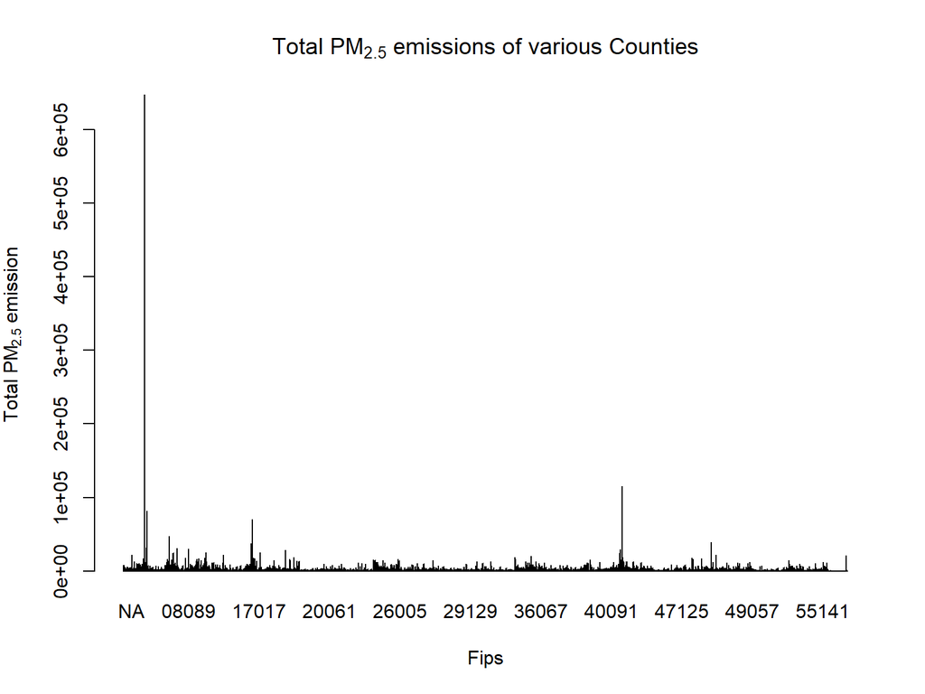

```r
#Combining the emission and fips column of the dataset using aggregrate function
nei <- readRDS("./R_course/summarySCC_PM25.rds")
aggregateTotalFips <- aggregate(Emissions~year+fips,nei,sum)
#Plotting it using barplot
barplot(height = aggregateTotalFips$Emissions,names.arg = aggregateTotalFips$fips,xlab="Fips", ylab=expression('Total PM'[2.5]*' emission'),main=expression('Total PM'[2.5]*' emissions of various Counties'))
```

```r
max(aggregateTotalFips$Emissions)
```

```
## [1] 647413.3
```

- County having maximum emission in this time period is Yukon-Koyukuk Cenus Area,AK

```r
min(aggregateTotalFips$Emissions)
```

```
## [1] 0
```

- There are Six counties having minimum emission i.e 0 tons.
- Washbaugh County
- Skagway-Yakutat-Angoon Census Area
- South Boston
- Dade County
- Kobuk census Area,AK
- Aletion Islands Census Area,AK

# Showing the counties having lowest and highest emission on world map

```r
library(leaflet)
library(dplyr)
leaflet() %>% addTiles() %>%
    addMarkers(
        lng = -149.4937, lat = 64.2008,
        label = "Alaska",
        labelOptions = labelOptions(noHide = T,textsize = "10px", direction = "bottom",
        style =
                                        list("color" = "red"))) %>%
    addMarkers(
        lng = -153.4303 ,lat = 65.844,
        label = "Yukon-Koyukuk Cenus Area,AK",
        labelOptions = labelOptions(noHide = T, textsize = "10px",direction="left",
         style =
                                        list("color" = "black"))) %>%
    addMarkers(
        lng = -80.6327 ,lat = 25.5516,
        label = " Dade county",
        labelOptions = labelOptions(noHide = T,textsize = "10px",
         style =
                                        list("color" = "red"))) %>%
    addMarkers(
        lng = -78.9014 ,lat = 36.6987,
        label = "South boston",
        labelOptions = labelOptions(noHide = T,direction = "right",
                                    style =
                                        list("color" = "red")))  %>%
    addMarkers(
        lng = -135.3153 , lat = 59.4554,
        label = "Skagway-Yakutat-Angoon Census Area",
        labelOptions = labelOptions(noHide = T, direction = "right",
                                    style =
                                        list("color" = "red")))
```

[interactive chart not shown]

# Comparing the counties having the maximum and minimum emission.

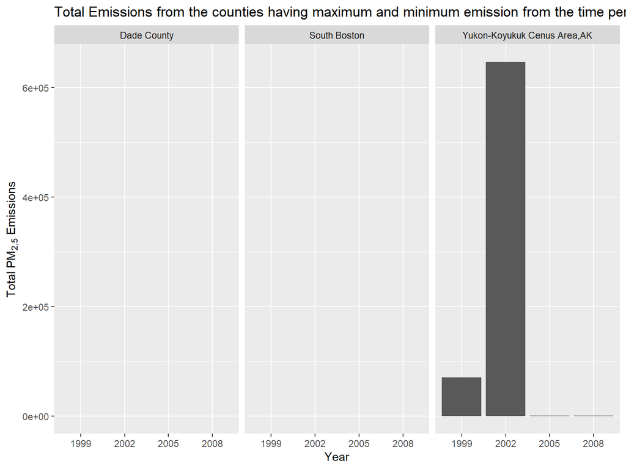

```r
if(!exists("NEI")){
    NEI <- readRDS("./R_Course/summarySCC_PM25.rds")
}
if(!exists("SCC")){
    SCC <- readRDS("./R_course/Source_Classification_Code.rds")
}


library(ggplot2)
library(ggplot2)

# 24510 is Baltimore, see plot2.R, 06037 is LA CA
# Searching for ON-ROAD type in NEI
# Don't actually know it this is the intention, but searching for 'motor' in SCC only gave a subset (non-cars)
subsetNEI <- NEI[(NEI$fips=="02290"|NEI$fips=="12025"|NEI$fips=="51780") , ]

aggregatedTotalByYearAndFips <- aggregate(Emissions ~ year + fips, subsetNEI, sum)
aggregatedTotalByYearAndFips$fips[aggregatedTotalByYearAndFips$fips=="02290"] <- "Yukon-Koyukuk Cenus Area,AK"
aggregatedTotalByYearAndFips$fips[aggregatedTotalByYearAndFips$fips=="12025"] <- "Dade County"
aggregatedTotalByYearAndFips$fips[aggregatedTotalByYearAndFips$fips=="51780"] <- "South Boston"

g <- ggplot(aggregatedTotalByYearAndFips, aes(factor(year), Emissions))
g <- g + facet_grid(. ~ fips)
g <- g + geom_bar(stat="identity") +
    xlab("Year") +
    ylab(expression('Total PM'[2.5]*" Emissions")) +
    ggtitle('Total Emissions from the counties having maximum and minimum emission from the time period 1999-2008')
plot(g)
```